# Predicting Barbell Exercise Quality

7 October 2026

## Objective

This analysis predicts `classe`, the manner in which a participant performed a barbell lift, from belt, arm, forearm, and dumbbell sensor measurements. Class A denotes correct execution and B-E denote four prescribed mistakes. The goal is to compare a simple classifier with a random forest, estimate performance on unseen recording windows, and predict the 20 unlabeled course cases.

## Data and validation design

The course provides a labeled training CSV and a separate 20-row testing CSV. The testing file has no observed `classe` and is not used for model selection or error estimation. The source is the Weight Lifting Exercise Dataset of Velloso and colleagues, cited below.

```r
base_url <- "https://d396qusza40orc.cloudfront.net/predmachlearn/"
data_dir <- Sys.getenv("PML_DATA_DIR", "data")
dir.create(data_dir, recursive = TRUE, showWarnings = FALSE)
read_course_data <- function(filename) {
  path <- file.path(data_dir, filename)
  if (!file.exists(path)) {
    download.file(paste0(base_url, filename), path, mode = "wb",
                  quiet = TRUE)
  }
  read.csv(path, na.strings = c("NA", "#DIV/0!", ""),
           stringsAsFactors = FALSE)
}
training_raw <- read_course_data("pml-training.csv")
testing_raw <- read_course_data("pml-testing.csv")
training_raw$classe <- factor(training_raw$classe, levels = LETTERS[1:5])
stopifnot(nrow(training_raw) == 19622, nrow(testing_raw) == 20)

group <- paste(training_raw$user_name, training_raw$num_window, sep = ":")
first <- !duplicated(group)
group_table <- data.frame(group = group[first],
                          classe = training_raw$classe[first])
stopifnot(all(vapply(split(training_raw$classe, group),
                     function(x) length(unique(x)), integer(1)) == 1))

build_groups <- unlist(lapply(split(group_table$group, group_table$classe),
                             function(x) sample(x, floor(0.75 * length(x)))),
                       use.names = FALSE)
in_build <- group %in% build_groups
stopifnot(length(intersect(unique(group[in_build]),
                           unique(group[!in_build]))) == 0)

candidate_names <- names(training_raw)[8:159]
usable <- vapply(training_raw[in_build, candidate_names], function(x) {
  is.numeric(x) && !anyNA(x) && length(unique(x)) > 1
}, logical(1))
predictor_names <- candidate_names[usable]
model_data <- training_raw[c(predictor_names, "classe")]
build <- model_data[in_build, ]
validation <- model_data[!in_build, ]
quiz <- testing_raw[predictor_names]
stopifnot(length(predictor_names) == 52, !anyNA(validation), !anyNA(quiz))

knitr::kable(data.frame(
  Class = levels(model_data$classe),
  Build = as.integer(table(build$classe)),
  Validation = as.integer(table(validation$classe))),
  caption = "Class counts after the grouped split")
```

Class counts after the grouped split

| Class | Build | Validation |
| --- | --- | --- |
| A | 4159 | 1421 |
| B | 2813 | 984 |
| C | 2491 | 931 |
| D | 2415 | 801 |
| E | 2751 | 856 |

There are 19622 labeled rows, 160 columns, six participants, and 858 participant/window groups. Repeated readings in a recording window are related. A random row split could therefore give an optimistic estimate. Approximately 75% of windows within each class were assigned to model building and the remainder to an untouched validation set. This produced 14629 build rows in 642 windows and 4993 validation rows in 216 windows.

The first seven fields are identifiers, participant names, timestamps, and window descriptors. They define groups but are excluded as predictors. Feature screening used only the build partition. The 52 retained measurements are numeric, complete, and nonconstant. Most excluded sensor summary fields are almost entirely missing. Selected measurements are also complete in validation and the quiz file, so no imputation is needed. Tree models do not require scaling. No feature selection used validation outcomes.

## Models and grouped cross-validation

A single classification tree provides an interpretable baseline. A random forest can capture nonlinear boundaries and interactions while averaging many trees to reduce variance. Five-fold cross-validation was performed within the build partition. Windows, stratified by class, were assigned to folds as whole groups. All candidate models used exactly the same folds.

For the forest, the number of candidate variables per split (`mtry`) was tested at 2, 7, and 14. Seven is near the square root of 52. Each tuning fit used 300 trees, Gini splitting, and a minimum node size of one. The baseline used `rpart` with complexity parameter 0.01. Mean fold accuracy selected the forest setting. The validation set did not participate in this decision.

```r
build_group_table <- group_table[group_table$group %in% build_groups, ]
build_group_table$fold <- 0L
for (class in levels(model_data$classe)) {
  idx <- which(build_group_table$classe == class)
  build_group_table$fold[idx] <- sample(rep(1:5, length.out = length(idx)))
}
row_fold <- build_group_table$fold[
  match(group[in_build], build_group_table$group)]
cv_results <- data.frame()
for (fold in 1:5) {
  fit_rows <- row_fold != fold
  test_rows <- !fit_rows
  tree <- rpart(classe ~ ., data = build[fit_rows, ], method = "class",
                control = rpart.control(cp = 0.01, xval = 0))
  tree_prediction <- predict(tree, build[test_rows, ], type = "class")
  cv_results <- rbind(cv_results, data.frame(
    Model = "Single tree", mtry = NA_integer_, Fold = fold,
    Accuracy = mean(tree_prediction == build$classe[test_rows])))
  for (m in c(2, 7, 14)) {
    forest <- ranger(classe ~ ., data = build[fit_rows, ],
                      num.trees = 300, mtry = m, min.node.size = 1,
                      splitrule = "gini", seed = 2026 + 100 * fold + m,
                      num.threads = 2)
    prediction <- predict(forest, build[test_rows, ])$predictions
    cv_results <- rbind(cv_results, data.frame(
      Model = "Random forest", mtry = m, Fold = fold,
      Accuracy = mean(prediction == build$classe[test_rows])))
  }
}
settings <- c("Single tree", "RF: mtry = 2", "RF: mtry = 7", "RF: mtry = 14")
cv_results$Setting <- ifelse(cv_results$Model == "Single tree", "Single tree",
                             paste0("RF: mtry = ", cv_results$mtry))
cv_summary <- do.call(rbind, lapply(settings, function(setting) {
  a <- cv_results$Accuracy[cv_results$Setting == setting]
  data.frame(Setting = setting, Mean_accuracy = mean(a),
             Fold_SD = sd(a), Mean_error = 1 - mean(a))
}))
best <- which.max(cv_summary$Mean_accuracy[-1])
best_mtry <- c(2, 7, 14)[best]
best_cv <- cv_summary$Mean_accuracy[best + 1]
cv_display <- cv_summary
cv_display[-1] <- lapply(cv_display[-1], function(x) sprintf("%.2f%%", 100 * x))
knitr::kable(cv_display, col.names = c("Model", "Mean accuracy",
                                      "Fold SD", "Mean error"))
```

| Model | Mean accuracy | Fold SD | Mean error |
| --- | --- | --- | --- |
| Single tree | 64.74% | 4.49% | 35.26% |
| RF: mtry = 2 | 90.91% | 2.60% | 9.09% |
| RF: mtry = 7 | 92.04% | 2.00% | 7.96% |
| RF: mtry = 14 | 92.48% | 1.95% | 7.52% |

The selected `mtry` is 14, with mean cross-validation accuracy 92.48% and estimated error 7.52%. The table distinguishes fold-to-fold standard deviation from a confidence interval. Tuning is limited to a small grid to keep the analysis practical and reproducible.

## Untouched validation performance

After choosing `mtry`, the forest was trained on the whole build partition with 500 trees. This increases ensemble size without using validation labels to tune the model. Accuracy and the confusion matrix were calculated once on the reserved windows.

```r
validation_model <- ranger(classe ~ ., data = build,
                            num.trees = 500, mtry = best_mtry,
                            min.node.size = 1, splitrule = "gini",
                            importance = "permutation", seed = 2026,
                            num.threads = 2)
validation_prediction <- predict(validation_model, validation)$predictions
cm <- table(Predicted = validation_prediction, Observed = validation$classe)
correct <- sum(diag(cm))
accuracy <- correct / sum(cm)
errors <- sum(cm) - correct
recall <- diag(cm) / colSums(cm)
knitr::kable(cm, caption = "Validation confusion matrix: rows predicted, columns observed")
```

Validation confusion matrix: rows predicted, columns observed

|  | A | B | C | D | E |
| --- | --- | --- | --- | --- | --- |
| A | 1404 | 42 | 0 | 0 | 0 |
| B | 10 | 905 | 18 | 9 | 10 |
| C | 0 | 27 | 913 | 48 | 3 |
| D | 7 | 10 | 0 | 724 | 15 |
| E | 0 | 0 | 0 | 20 | 828 |

```r
knitr::kable(data.frame(Class = names(recall), Recall = sprintf("%.2f%%", 100 * recall)))
```

| Class | Recall |
| --- | --- |
| A | 98.80% |
| B | 91.97% |
| C | 98.07% |
| D | 90.39% |
| E | 96.73% |

```r
validation_group <- group[!in_build]
window_correct <- tapply(validation_prediction == validation$classe,
                         validation_group, sum)
window_n <- table(validation_group)[names(window_correct)]
set.seed(2027)
bootstrap_accuracy <- replicate(2000, {
  idx <- sample.int(length(window_correct), replace = TRUE)
  sum(window_correct[idx]) / sum(window_n[idx])
})
accuracy_ci <- quantile(bootstrap_accuracy, c(0.025, 0.975))
```

The model correctly classified 4774 of 4993 validation readings, with 219 errors. **Validation accuracy is 95.61% and estimated out-of-sample error is 4.39%.** A percentile bootstrap resampling the validation windows 2,000 times gives an approximate 95% accuracy interval of 93.62% to 97.35%. Resampling whole windows preserves within-window dependence. The interval reflects validation sampling uncertainty conditional on the fitted model, not all model-selection uncertainty.

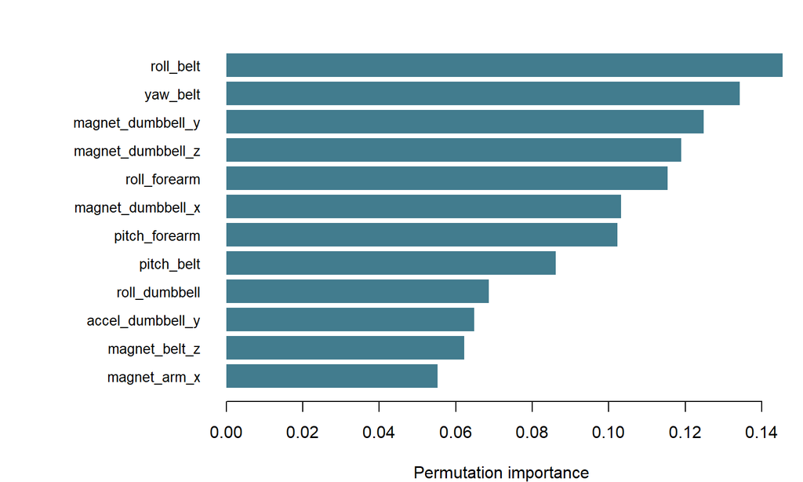

Top 12 measurements by permutation importance in the build-partition forest. Importance describes predictive contribution, not causality.

The highest-ranked measurement is roll_belt. Permutation importance can be affected by correlated sensors, so the ranking is descriptive. The single-tree comparison and the holdout assessment provide separate evidence for choosing the forest.

## Predictions for the 20 course cases

Only after validation was complete, a final 500-tree forest with the selected settings was fitted to all labeled rows. The same 52 predictors were retained. The table is sorted by `problem_id`, rather than relying on file row order.

```r
final_model <- ranger(classe ~ ., data = model_data,
                       num.trees = 500, mtry = best_mtry,
                       min.node.size = 1, splitrule = "gini",
                       seed = 2028, num.threads = 2)
quiz_prediction <- predict(final_model, quiz)$predictions
answers <- data.frame(problem_id = testing_raw$problem_id,
                      prediction = as.character(quiz_prediction))
answers <- answers[order(answers$problem_id), ]
stopifnot(identical(answers$problem_id, 1:20),
           all(answers$prediction %in% LETTERS[1:5]))
knitr::kable(answers)
```

| problem_id | prediction |
| --- | --- |
| 1 | B |
| 2 | A |
| 3 | B |
| 4 | A |
| 5 | A |
| 6 | E |
| 7 | D |
| 8 | B |
| 9 | A |
| 10 | A |
| 11 | B |
| 12 | C |
| 13 | B |
| 14 | A |
| 15 | E |
| 16 | E |
| 17 | A |
| 18 | B |
| 19 | B |
| 20 | B |

```r
writeLines(paste(answers$problem_id, answers$prediction, sep = ": "),
            "predictions.txt")
```

Predictions in problem order: **B, A, B, A, A, E, D, B, A, A, B, C, B, A, E, E, A, B, B, B**.

## Conclusion and limitations

The random forest predicts exercise class with an estimated error of 4.39% on reserved recording windows. This is an estimate for similar measurements under the study protocol, not a guarantee for each quiz case. No labels are available to measure accuracy on the 20 course cases.

Window grouping reduces one source of leakage, but the build and validation partitions still contain the same six participants. Nearby windows may also be related. Performance for new people, recording sessions, or devices may be lower. A larger study with participant- or session-held-out validation would be needed for a deployment claim.

## Reproducibility and sources

The report was compiled with `knitr` and `rmarkdown`. To reproduce it, install `rmarkdown`, `knitr`, `ranger`, and `rpart`, then run `rmarkdown::render("Prediction_Assignment_Writeup.Rmd")` from the project directory. Missing data files are downloaded from the course links. Fixed seeds specify splitting and model fitting. The HTML includes evaluated results and one figure, so peer reviewers do not need to run R.

Velloso, E., Bulling, A., Gellersen, H., Ugulino, W., and Fuks, H. (2013). *Qualitative Activity Recognition of Weight Lifting Exercises*. Proceedings of the 4th Augmented Human International Conference, pp. 116-123. [DOI: 10.1145/2459236.2459256](https://doi.org/10.1145/2459236.2459256). [Archived dataset description](https://web.archive.org/web/20161224072740/http://groupware.les.inf.puc-rio.br/har).

Data: [training CSV](https://d396qusza40orc.cloudfront.net/predmachlearn/pml-training.csv) and [testing CSV](https://d396qusza40orc.cloudfront.net/predmachlearn/pml-testing.csv).